# Bootstrapping

Lawson Busch

10/2/2018

## Bootstrapping Example

Using this sample of 27 MAC students, estimate the population of all Mac students. (CLT most likely won’t hold.)

```r
students <- c("Rohit", "Milo", "Lawson", "Yuxiang", "Sean",
              "Emma", "Sebastian", "Mark", "Cuau", "Andrew",
              "Joe", "Jin", "Erle", "Esteban", "Tianyou",
              "Kieran", "Graham", "Raven", "Sofia", "Risa",
              "Ximena", "Zach", "Mia", "Zhen", "Onur",
              "Ruiqi", "Xuchen")
length(students)
```

```
## [1] 27
```

To take a sample: We want to take a sample that is the same size as our actual sample (assumes we have a bunch of samples of 27 people). Problem with this is that it is the same data, just a different order.

```r
library(dplyr)
```

```r
library(ggplot2)
sample(students, size = 27, replace = FALSE)
```

```
##  [1] "Tianyou"   "Erle"      "Milo"      "Raven"     "Emma"
##  [6] "Zhen"      "Rohit"     "Lawson"    "Onur"      "Andrew"
## [11] "Mia"       "Yuxiang"   "Mark"      "Ximena"    "Sofia"
## [16] "Xuchen"    "Zach"      "Graham"    "Risa"      "Sebastian"
## [21] "Sean"      "Cuau"      "Esteban"   "Jin"       "Ruiqi"
## [26] "Kieran"    "Joe"
```

So to get the idea of Bootstrapping, we can sample with replacement:

```r
sample(students, size = 27, replace = TRUE)
```

```
##  [1] "Zhen"      "Cuau"      "Risa"      "Ruiqi"     "Sebastian"
##  [6] "Sofia"     "Milo"      "Xuchen"    "Tianyou"   "Milo"
## [11] "Xuchen"    "Onur"      "Ximena"    "Zach"      "Lawson"
## [16] "Kieran"    "Kieran"    "Mark"      "Mia"       "Jin"
## [21] "Cuau"      "Risa"      "Sean"      "Joe"       "Raven"
## [26] "Sebastian" "Mia"
```

In bootstrapping, we just resample over and over and over to imitate a true sampling distribution.

Ultimate goal is to understand variation from sample to sample without assumption of normality. By resampling and calculating distribution for each sample, we get the Bootstrap distribution.

We can then use the Bootstrap distribution (which is slightly different than the sampling distribution, aka not centered at the true $Beta$), to calculate confidence intervals and P-values. While we might not get the right location, we get the right spread.

## Excercises

One way to do resampling (our own code):

```
slopes <- rep(0, 1000)
for(i in 1:1000){
    # Take a resample
    resamp <- sample_n(data, size = n, replace = TRUE)

    # Fit a model using the resample
    remod <- lm(y ~ x, data = resamp)

    # Store the slope
    slopes[i] <- coef(remod)[1]
}

# Check out the 1000 slopes
slopes
```

But we have functions that can do this in tidyverse packages:

```r
joy <- read.csv("https://www.macalester.edu/~ajohns24/data/joy_division.csv")

joy %>%
    summarize(mean(track_popularity))
```

```
##   mean(track_popularity)
## 1                   40.5
```

```r
joy %>%
    summarize(max(tempo))
```

```
##   max(tempo)
## 1    179.472
```

The summarize function adds up all rows of the specified columns in a data frame and then performs an operation on them.

The group by verb tells summarize to group by a categorical variable. To find the fastest tempo on each album we can:

```r
joy %>%
    group_by(album_name) %>%
    summarize(max(tempo))
```

```
## # A tibble: 3 x 2
##   album_name        `max(tempo)`
##   <fct>                    <dbl>
## 1 Closer                     152
## 2 Les Bains Douches          179
## 3 Unknown Pleasures          156
```

## Group by with do()

```r
# Load broom package for tidy()
library(broom)

joy %>%
    do(lm(track_popularity ~ tempo, data = .) %>% tidy())
```

```
##          term   estimate  std.error  statistic      p.value
## 1 (Intercept) 49.2367079 9.67696998  5.0880294 1.538403e-05
## 2       tempo -0.0655155 0.07150352 -0.9162556 3.663867e-01
```

The do() function allows you to specify a computation to perform on a data frame.

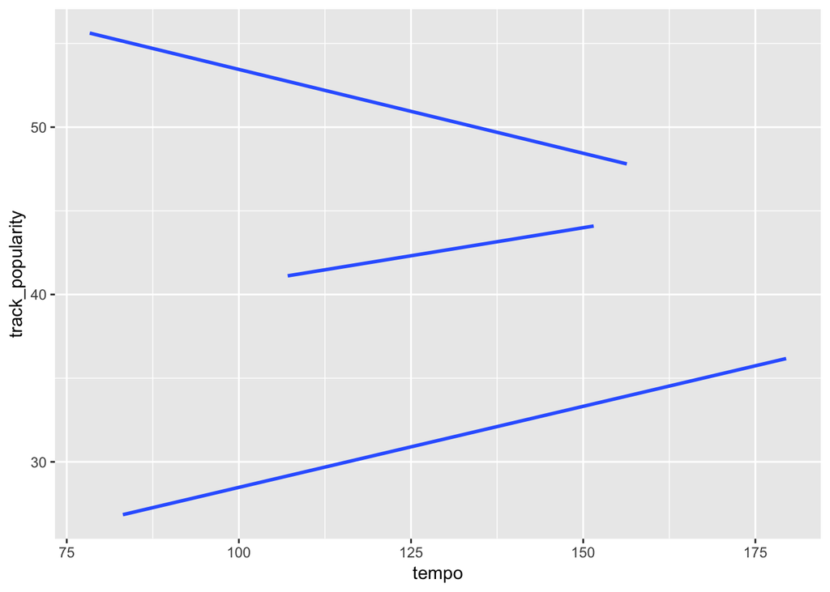

```r
ggplot(joy, aes(x = tempo, y = track_popularity, group = album_name)) +
    geom_smooth(method = "lm", se = FALSE)
```

Models group_by album name.

```r
album_models <- joy %>%
  group_by(album_name) %>%
  do(lm(track_popularity ~ tempo, data = .) %>% tidy())
```

Keep only terms with the Intercept.

```r
album_models <- joy %>%
  group_by(album_name) %>%
  do(lm(track_popularity ~ tempo, data = .) %>% tidy()) %>%
  filter(term == '(Intercept)')
```

## Focus on the closer album

```r
joy_sub <- joy %>%
    filter(album_name == "Closer")
```

```r
# Load the infer package
library(infer)
#Takes a sample of size three no replace one time
rep_sample_n(joy_sub, size = 3, replace = FALSE, reps = 1)
```

```
## # A tibble: 3 x 17
## # Groups:   replicate [1]
##   replicate album_name album_release_da… track_name           track_number
## *     <int> <fct>      <fct>             <fct>                       <int>
## 1         1 Closer     1980              A Means To An End -…            5
## 2         1 Closer     1980              The Eternal - 2007 …            8
## 3         1 Closer     1980              Twenty Four Hours -…            7
## # ... with 12 more variables: danceability <dbl>, energy <dbl>,
## #   loudness <dbl>, mode <fct>, speechiness <dbl>, acousticness <dbl>,
## #   instrumentalness <dbl>, liveness <dbl>, valence <dbl>, tempo <dbl>,
## #   duration_ms <int>, track_popularity <int>
```

```r
#Takes a sample of size three no replace two times
rep_sample_n(joy_sub, size = 3, replace = FALSE, reps = 2)
```

```
## # A tibble: 6 x 17
## # Groups:   replicate [2]
##   replicate album_name album_release_da… track_name           track_number
## *     <int> <fct>      <fct>             <fct>                       <int>
## 1         1 Closer     1980              Heart And Soul - 20…            6
## 2         1 Closer     1980              Colony - 2007 Remas…            4
## 3         1 Closer     1980              Atrocity Exhibition…            1
## 4         2 Closer     1980              The Eternal - 2007 …            8
## 5         2 Closer     1980              Colony - 2007 Remas…            4
## 6         2 Closer     1980              Isolation - 2007 Re…            2
## # ... with 12 more variables: danceability <dbl>, energy <dbl>,
## #   loudness <dbl>, mode <fct>, speechiness <dbl>, acousticness <dbl>,
## #   instrumentalness <dbl>, liveness <dbl>, valence <dbl>, tempo <dbl>,
## #   duration_ms <int>, track_popularity <int>
```

```r
#Takes a sample of size three with replace one time
rep_sample_n(joy_sub, size = 3, replace = TRUE, reps = 1)
```

```
## # A tibble: 3 x 17
## # Groups:   replicate [1]
##   replicate album_name album_release_da… track_name           track_number
## *     <int> <fct>      <fct>             <fct>                       <int>
## 1         1 Closer     1980              Heart And Soul - 20…            6
## 2         1 Closer     1980              Colony - 2007 Remas…            4
## 3         1 Closer     1980              Heart And Soul - 20…            6
## # ... with 12 more variables: danceability <dbl>, energy <dbl>,
## #   loudness <dbl>, mode <fct>, speechiness <dbl>, acousticness <dbl>,
## #   instrumentalness <dbl>, liveness <dbl>, valence <dbl>, tempo <dbl>,
## #   duration_ms <int>, track_popularity <int>
```

```r
#Takes a sample of size three with replace two times
rep_sample_n(joy_sub, size = 3, replace = TRUE, reps = 2)
```

```
## # A tibble: 6 x 17
## # Groups:   replicate [2]
##   replicate album_name album_release_da… track_name           track_number
## *     <int> <fct>      <fct>             <fct>                       <int>
## 1         1 Closer     1980              Atrocity Exhibition…            1
## 2         1 Closer     1980              Decades - 2007 Rema…            9
## 3         1 Closer     1980              Heart And Soul - 20…            6
## 4         2 Closer     1980              Twenty Four Hours -…            7
## 5         2 Closer     1980              A Means To An End -…            5
## 6         2 Closer     1980              Colony - 2007 Remas…            4
## # ... with 12 more variables: danceability <dbl>, energy <dbl>,
## #   loudness <dbl>, mode <fct>, speechiness <dbl>, acousticness <dbl>,
## #   instrumentalness <dbl>, liveness <dbl>, valence <dbl>, tempo <dbl>,
## #   duration_ms <int>, track_popularity <int>
```

100 resamples of the joy_sub: We use the number of rows as the size of each resample, with replacement, and do this 100 times.

```r
n = nrow(joy_sub)
joy_resamples <- rep_sample_n(joy_sub, size = n, replace = TRUE, reps = 100)
```

Plotting the resampled models:

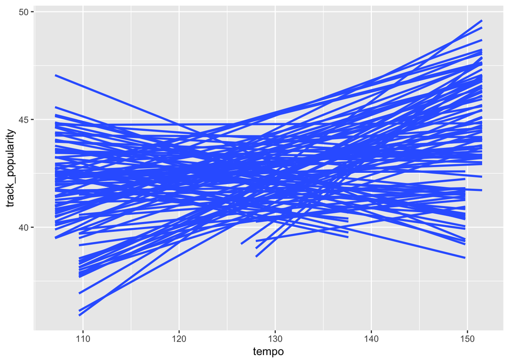

```r
ggplot(joy_resamples, aes(x = tempo, y = track_popularity, group = replicate)) +
    geom_smooth(method = "lm", se = FALSE)
```

To get the model coefficeints:

```r
tempo_models <- joy_resamples %>%
  group_by(replicate) %>%
  do(lm(track_popularity ~ tempo, data = .) %>% tidy())

head(tempo_models)
```

```
## # A tibble: 6 x 6
## # Groups:   replicate [3]
##   replicate term         estimate std.error statistic  p.value
##       <int> <chr>           <dbl>     <dbl>     <dbl>    <dbl>
## 1         1 (Intercept)  15.1       10.0       1.50   0.176
## 2         1 tempo         0.206      0.0741    2.78   0.0271
## 3         2 (Intercept)  55.8        8.24      6.78   0.000259
## 4         2 tempo       - 0.102      0.0634   -1.62   0.150
## 5         3 (Intercept)  44.4       13.1       3.39   0.0115
## 6         3 tempo       - 0.00156    0.102    -0.0153 0.988
```